# AirBNB Data Presentation

13/12/2019

## Intro

The purpose of this analysis and project was to visualize and draw conclusions of the tendencies that AirBNB listings generally follow, in primarily the eastern side of the USA. Cities include:

- Boston
- New York
- Philadelphia
- Miami
- Nashville
- Houston
- Washington DC.

## Intro cont’d

This presentation will summarize analysis run on the data. Analysis that was run includes:

- EDA
- EFA
- Mapping
- Database Creation

## The Data

The data used includes unique id information in the each listing, the review numbers for each listing, how many bedrooms and the number of people it accomodates and more. Columns 1-6:

| X | room_id | host_id | room_type | reviews | accommodates |
| --- | --- | --- | --- | --- | --- |
| 1 | 12784064 | 3137257 | Entire home/apt | 28 | 5 |
| 2 | 3755609 | 19223882 | Private room | 22 | 1 |
| 3 | 990668 | 1651480 | Private room | 112 | 2 |
| 4 | 3968797 | 4762495 | Private room | 30 | 2 |
| 5 | 2915643 | 14891491 | Entire home/apt | 1 | 4 |
| 6 | 17909550 | 1118374 | Entire home/apt | 0 | 3 |

## The Data

Remaining columns 7-12:

| bedrooms | price | latitude | longitude | last_modified | City |
| --- | --- | --- | --- | --- | --- |
| 2 | 200 | 42.36467 | -71.05576 | 2017-04-08 15:58:44.097503 | Boston |
| 1 | 72 | 42.27564 | -71.12480 | 2017-04-08 15:12:31.579145 | Boston |
| 1 | 93 | 42.34146 | -71.07641 | 2017-04-08 15:19:30.478553 | Boston |
| 1 | 85 | 42.29111 | -71.13134 | 2017-04-08 15:24:35.994515 | Boston |
| 1 | 289 | 42.34954 | -71.07849 | 2017-04-08 16:04:58.840221 | Boston |
| 0 | 197 | 42.35127 | -71.12563 | 2017-04-08 15:58:44.977045 | Boston |

## EDA

Firstly, we wanted to explore the listing price distributions, based on the different cities we have access to.

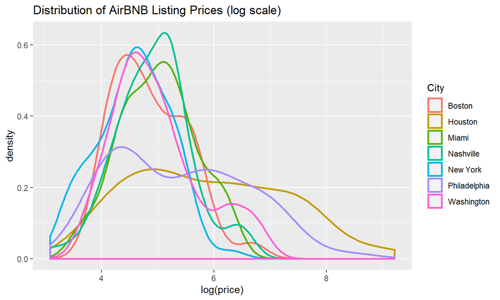

## EDA

We could see from this density plot:

- Majority of listing prices amongst all cities lie between *[55$ - 245$]* dollars/night.
- Houston and Philly have the largest variance and spread in prices overall
- Houston data contains the most expensive listings out of all cities.

## EDA

In addition, we then looked at the distribution of room types amongst cities.

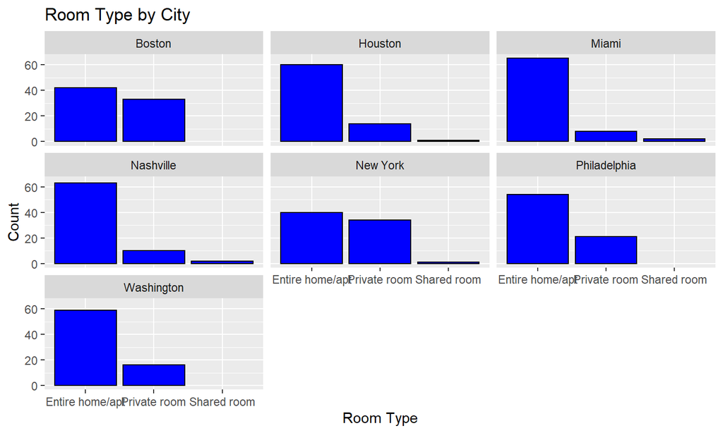

## EDA

We could see from these histograms:

- Among entire 7 city data set, more ‘Entire home/apt’ listings than shared and private rooms combined.
- Boston and New York come closest to equal number of ‘Entire home/apt’ listings and “Private room” listings.

## EDA

Finally, taking a look at the distribution of accommodation numbers across all cities.

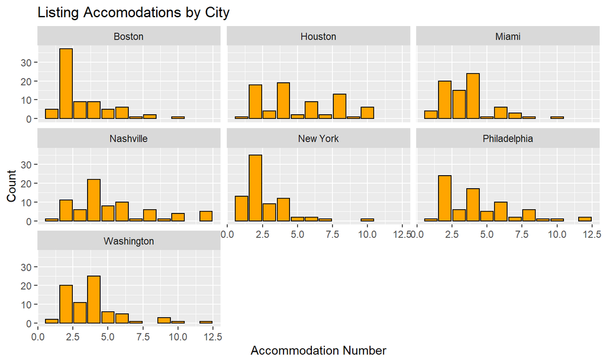

## EDA

From these histograms, we can see:

- Boston and New York have the highest concentration of listings below 2.5 people accommodating. (helping explain previous visual showing their similar number of ‘Entire Homes’ to ‘Private Rooms’ listings
- Houston has the largest relatively equal spread of listing accommodations, ranging from around 2-10 people. (helping explain the large spread of price in the previous density plot)

## EFA

we will run factor analysis on our numerical variable’s in our BNB data, to see if we could hypothetically reduce dimensionality. The numerical variables of interest were:

- accommodates
- bedrooms
- reviews
- price
- longitude
- latitude

## EFA

Given our 6 variables in total, we looked at the results from combining to 3 components, to see how the variables would group together (if at all).

```
##
## Call:
## factanal(x = BNB_factor, factors = 3, rotation = "varimax")
##
## Uniquenesses:
##        price     latitude    longitude accommodates     bedrooms
##         0.71         0.00         0.45         0.00         0.25
##      reviews
##         0.96
##
## Loadings:
##              Factor1 Factor2 Factor3
## accommodates  0.97
## bedrooms      0.73            0.47
## latitude              1.00
## longitude             0.65   -0.31
## price                         0.43
## reviews
##
##                Factor1 Factor2 Factor3
## SS loadings       1.59    1.45    0.58
## Proportion Var    0.26    0.24    0.10
## Cumulative Var    0.26    0.51    0.60
##
## The degrees of freedom for the model is 0 and the fit was 0.0077
```

## EFA

Now, looking at the scree plot to determine the optimal number of factors to extract from these variables.

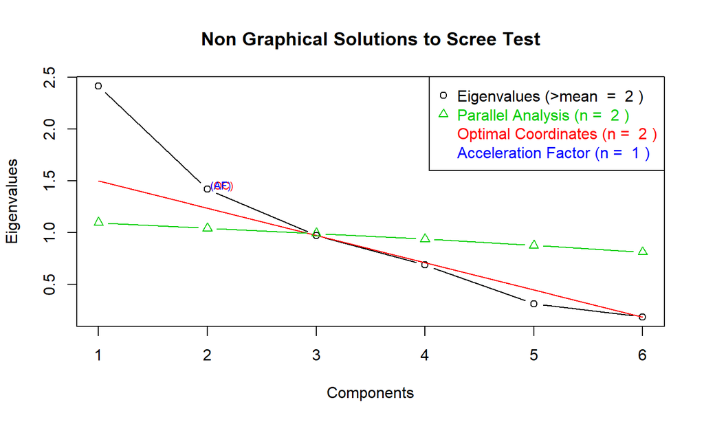

## Mapping

Now, we want to begin to look further into how these listings are arranged in their respective cities proximity-wise. *(Below is a screenshot of the map created, the interactive leaflet map will be available in the Shiny app along with this presentation)*

[figure not shown]

## SQL Data Base

- In the case where we would like to make listings easily accessible through queries, one way we can do this is by building a RSQLite database.
- For this current BNB data, the database would be relatively simple with only two tables needed:
- Table 1: *listing = (BNB, room_id, host_id, latitude, longitude, City)*
- Table 2: *room = (BNB, room_id, reviews, accommodates, bedrooms, price, room_type)*
- Organizing the data into a database will allow for quick querying, especially for someone not as familiar in R coding, as this allows the querying to then be done in DB browser.
- Interactive queries will be available in the Shiny app corresponding to this presentation